# Prosper Loans Data Visualization

### By: Mina Karam

## Data Analysis :

> For prosper loans of a famous american bank.

#### Navigation :

> You can navigate through this slideshow using the board appears at the bottom-right corner, or by using the keyboard arrows.  
> You can click on any graph to show the code used to produce it.

# Dataset overview :

## Dataset :

```python
original_df.head(5)
```

|  | ListingKey | ListingNumber | ListingCreationDate | CreditGrade | Term | LoanStatus | ClosedDate | BorrowerAPR | BorrowerRate | LenderYield | ... | LP_ServiceFees | LP_CollectionFees | LP_GrossPrincipalLoss | LP_NetPrincipalLoss | LP_NonPrincipalRecoverypayments | PercentFunded | Recommendations | InvestmentFromFriendsCount | InvestmentFromFriendsAmount | Investors |
| --- | --- | --- | --- | --- | --- | --- | --- | --- | --- | --- | --- | --- | --- | --- | --- | --- | --- | --- | --- | --- | --- |
| 0 | 1021339766868145413AB3B | 193129 | 2007-08-26 19:09:29.263000000 | C | 36 | Completed | 2009-08-14 00:00:00 | 0.16516 | 0.1580 | 0.1380 | ... | -133.18 | 0.0 | 0.0 | 0.0 | 0.0 | 1.0 | 0 | 0 | 0.0 | 258 |
| 1 | 10273602499503308B223C1 | 1209647 | 2014-02-27 08:28:07.900000000 | NaN | 36 | Current | NaN | 0.12016 | 0.0920 | 0.0820 | ... | 0.00 | 0.0 | 0.0 | 0.0 | 0.0 | 1.0 | 0 | 0 | 0.0 | 1 |
| 2 | 0EE9337825851032864889A | 81716 | 2007-01-05 15:00:47.090000000 | HR | 36 | Completed | 2009-12-17 00:00:00 | 0.28269 | 0.2750 | 0.2400 | ... | -24.20 | 0.0 | 0.0 | 0.0 | 0.0 | 1.0 | 0 | 0 | 0.0 | 41 |
| 3 | 0EF5356002482715299901A | 658116 | 2012-10-22 11:02:35.010000000 | NaN | 36 | Current | NaN | 0.12528 | 0.0974 | 0.0874 | ... | -108.01 | 0.0 | 0.0 | 0.0 | 0.0 | 1.0 | 0 | 0 | 0.0 | 158 |
| 4 | 0F023589499656230C5E3E2 | 909464 | 2013-09-14 18:38:39.097000000 | NaN | 36 | Current | NaN | 0.24614 | 0.2085 | 0.1985 | ... | -60.27 | 0.0 | 0.0 | 0.0 | 0.0 | 1.0 | 0 | 0 | 0.0 | 20 |

5 rows × 81 columns

## Done by :

> Mina Karam  
> (Data Analyst)

# Investigation overview :

## Investigation :

The analysis process will focus on fundamental aspects of the data provided, answering obvious questions and through the presentation progress, we will be answering more complex questions.

Some of these questions are:

> Which year, month and day were preferred by loaners ?  
> What are loaners segments and how much they contribute to the total figures ?  
> How to increase the loan sums of the bank ?  
> What segments of loaners the bank should focus on?  
> and more...

## Visualization 1:

## Loans counts through the years

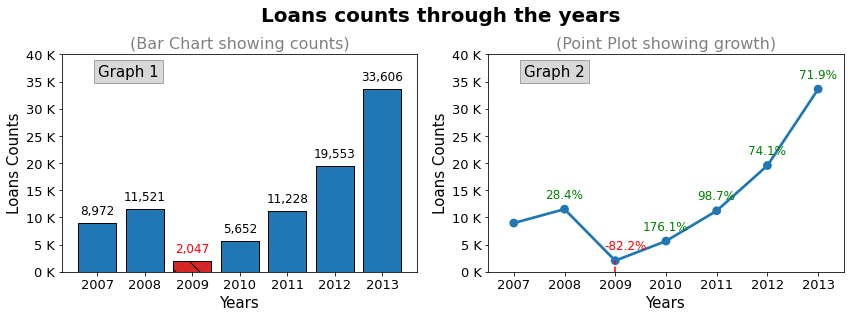

```python
plt.figure(figsize=(14,4))

plt.subplot(1,2,1)
plt.suptitle('Loans counts through the years', fontsize=20, fontweight='bold', va='bottom')
plt.title('(Bar Chart showing counts)', fontsize=16, color='grey')

clrs = [alt_color if x== df.year.value_counts()[2009] else color for x in df.year.value_counts(ascending=False)]
bars=plt.bar(height=df.year.value_counts(),x=df.year.value_counts().index, color=clrs, edgecolor='black', hatch=(''))
plt.xticks(fontsize=13)
plt.draw()
locs, labels = plt.yticks()
labels = [str(round(float(x.get_text())/1000))+' K' for x in labels]
plt.yticks(locs, labels, fontsize=13)
plt.ylabel('Loans Counts', fontsize=15)
plt.xlabel('Years', fontsize=15)
for i in range(2007,2014):
    counts= df.year.value_counts(sort=False)[i]
    txt=  '{:,d}'.format(counts)
    if i==2009:
        plt.text(i, counts+1000, txt, ha='center', va='bottom', color='r', fontsize=12)
    else:
        plt.text(i, counts+1000, txt, ha='center', va='bottom', color='black', fontsize=12)
pattern = ['','', '','','','','\\']
for bar, pattern in zip(bars, pattern):
    bar.set_hatch(pattern)
plt.text(0.1,0.9, 'Graph 1', transform= plt.gca().transAxes, color='black', fontsize=15, bbox= {'facecolor': 'grey','alpha': 0.3})

plt.subplot(1,2,2)
sb.pointplot(data=df, x=df.year.value_counts().index, y=df.year.value_counts(), color= color)
#plt.ylim(0,df.year.value_counts().max()+5000)
plt.draw()
locs, labels = plt.yticks()
labels = [str(round(float(x.get_text())/1000))+ ' K' for x in labels]
plt.yticks(locs, labels, fontsize=13)
plt.xticks(fontsize=13)
plt.axvline(2, color='r', ls='--', ymax=0.05)
plt.title('(Point Plot showing growth)', fontsize=16, color='grey')
plt.ylabel('Loans Counts', fontsize=15)
plt.xlabel('Years', fontsize=15)
plt.text(0.1,0.9, 'Graph 2', transform= plt.gca().transAxes, color='black', fontsize=15, bbox= {'facecolor': 'grey','alpha': 0.3})

for i in range(0,df.year.value_counts().shape[0]):
    if i in [1,3,4,5,6]:
        counts= df.year.value_counts(sort=False).values[i] - df.year.value_counts(sort=False).values[i-1]
        percentages= counts/df.year.value_counts(sort=False).values[i-1] *100
        txt=  ("%.1f" % percentages) +'%'
        plt.text(i, df.year.value_counts(sort=False).values[i]+1500, txt, ha='center', va='bottom', color='green', fontsize=12)
    elif i==2:
        counts= df.year.value_counts(sort=False).values[i] - df.year.value_counts(sort=False).values[i-1]
        percentages= counts/df.year.value_counts(sort=False).values[i-1] *100
        txt=  ("%.1f" % percentages) +'%'
        plt.text(i+0.2, df.year.value_counts(sort=False).values[i]+1500, txt, ha='center', va='bottom', color='r', fontsize=12)
plt.show()
```

# Observations :

> The graphs show a gradual positive growth through the years with a major drop in year (2009) with over 80% negative growth, that drop needs a further investigation.

Observations :  
The graphs show a gradual positive growth through the years with a major drop in year (2009) with over 80% negative growth, that drop needs a further investigation.

## Visualization 2:

## Loans counts through years and months

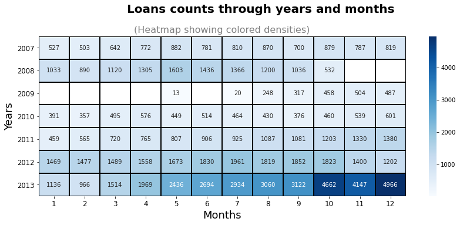

```python
plt.figure(figsize=(14,5))
plt.suptitle('Loans counts through years and months', fontsize=20, fontweight='bold', va='bottom')
plt.title('(Heatmap showing colored densities)', fontsize=16, color='grey')
sb.heatmap(x2, annot=True,fmt='.0f',cmap='Blues',linewidths=1, linecolor='black', cbar=True)
plt.xticks(fontsize=13)
plt.yticks(fontsize=11.5, rotation=0)
plt.xlabel('Months', fontsize=18)
plt.ylabel('Years', fontsize=18)
plt.xticks(fontsize=12);
```

# Observations :

> The graphs show a gradual increase through the years with a major drop beginning from oct./2008 till Aug./2009 followed by a healthy gradual increase afterward. This sharp decline might by of external national cause or internal bank-policy one.

## Visualization 3:

## Loans counts through the Quarters, Months and days

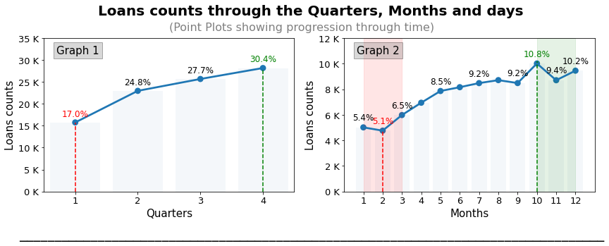

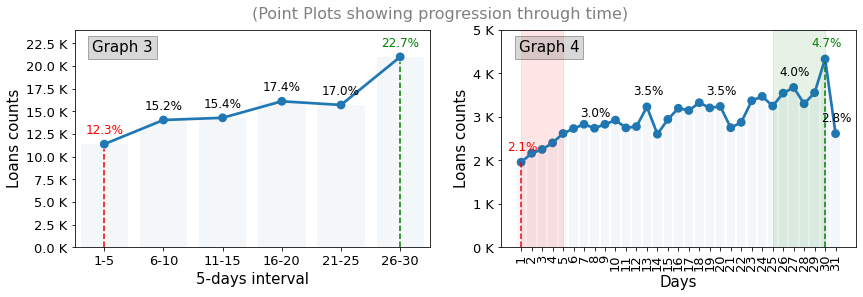

```python
plt.figure(figsize=(14,4))
plt.suptitle('Loans counts through the Quarters, Months and days', fontsize=20,va='bottom', fontweight='bold')
plt.title('(Point Plots showing percentages)', fontsize=16, color='grey')

plt.subplot(1,2,1)
sb.pointplot(data=df, x=df.quarter.value_counts().index, y=df.quarter.value_counts(), color= color)
sb.countplot(data=df, x='quarter', color=color, alpha=0.05)
plt.ylim(0,33000)

for i in np.arange(0, df.quarter.value_counts().shape[0]):
    counts= df.quarter.value_counts(sort=False).values[i]
    percentages= counts*100/df.shape[0]
    txt=  ("%.1f" % percentages) + '%'
    if i ==0:
        plt.text(i, counts+2000, txt, ha='center', va='center', color='r', fontsize=12)
    elif i ==3:
        plt.text(i, counts+1000, txt, ha='center', va='bottom', color='green', fontsize=12)
    else:
        plt.text(i, counts+2000, txt, ha='center', va='center', color='black', fontsize=12)
plt.text(0.05,0.9, 'Graph 1', transform= plt.gca().transAxes, color='black', fontsize=15, bbox= {'facecolor': 'grey','alpha': 0.3});
plt.draw()
locs, labels = plt.yticks()
labels = [str(round(float(x.get_text())/1000))+' K' for x in labels]
plt.yticks(locs, labels,fontsize=13)
plt.xticks(fontsize=13)
plt.xlabel('Quarters', fontsize=15)
plt.ylabel('Loans counts', fontsize=15)
plt.axvline(0,color='r', ymax=0.45, ls=('--'))
plt.axvline(3,color='green', ymax=0.8, ls=('--'))

plt.subplot(1,2,2)
sb.countplot(data=df, x='month', color=color, alpha=0.05)
sb.pointplot(data=df, x=df.month.value_counts().index, y=df.month.value_counts(), color= color)
plt.ylim(0,11000)
plt.draw()
locs, labels = plt.yticks()
labels = [str(round(float(x.get_text())/1000))+' K' for x in labels]
plt.yticks(locs, labels, fontsize=13)
plt.xticks(fontsize=13)
plt.xlabel('Months', fontsize=15)
plt.ylabel('Loans counts', fontsize=15)
for i in np.arange(0, df.month.value_counts().shape[0]):
    counts= df.month.value_counts(sort=False).values[i]
    percentages= counts*100/df.shape[0]
    txt=  ("%.1f" % percentages) +'%'
    if i ==1:
        plt.text(i, counts+400, txt, ha='center', va='bottom', color='r', fontsize=12)
    elif i ==9:
        plt.text(i, counts+400, txt, ha='center', va='bottom', color='green', fontsize=12)
    elif i in [0,2,4,6,8,10,11]:
        plt.text(i, counts+400, txt, ha='center', va='bottom', color='black', fontsize=12)
plt.axvline(1,color='r', ymax=0.4, ls=('--'))
plt.axvline(9,color='green', ymax=0.85, ls=('--'))
plt.text(0.05,0.9, 'Graph 2', transform= plt.gca().transAxes, color='black', fontsize=15, bbox= {'facecolor': 'grey','alpha': 0.3})
plt.axvspan(9,11, color='green', alpha=0.1)
plt.axvspan(0,2, color='red', alpha=0.1)
plt.text(-1.3,-0.3, '_'*82, transform= plt.gca().transAxes, color='black', fontsize=20)
plt.text(-0.7,1.05, '(Point Plots showing progression through time)', transform= plt.gca().transAxes, color='grey', fontsize=16)


plt.figure(figsize=(14,4))
plt.subplot(1,2,1)
sb.countplot(data=df, x='int', color=color, alpha=0.05)
sb.pointplot(data=df, x=df.int.value_counts().index, y=df.int.value_counts())
plt.draw()
locs,labels = plt.xticks()
labels=['1-5', '6-10', '11-15', '16-20', '21-25', '26-30']
plt.xticks(locs, labels, fontsize=13);
plt.xlabel('5-days interval', fontsize=15)
plt.ylabel('Loans counts', fontsize=15)
ax=0
for i in np.arange(2.5,28,5):
    counts= df.int.value_counts()[i]
    percentages= counts*100/df.shape[0]
    txt=  ("%.1f" % percentages)+ '%'
    if i ==2.5:
        plt.text(0, counts+1500, txt, ha='center', va='center', color='r', fontsize=12)
    elif i ==27.5:
        plt.text(5, counts+1500, txt, ha='center', va='center', color='green', fontsize=12)
    else:
        plt.text(ax, counts+1500, txt, ha='center', va='center', color='black', fontsize=12)
    ax+=1
locs, labels = plt.yticks()
labels = [str(float(x.get_text())/1000)+' K' for x in labels]
plt.yticks(locs, labels,fontsize=13)
plt.ylim(0,24000)
plt.axvline(0,color='r', ymax=0.45, ls=('--'))
plt.axvline(5,color='green', ymax=0.85, ls=('--'))
plt.text(0.05,0.9, 'Graph 3', transform= plt.gca().transAxes, color='black', fontsize=15, bbox= {'facecolor': 'grey','alpha': 0.3});


plt.subplot(1,2,2)
sb.countplot(data=df, x='day', color=color, alpha=0.05)
sb.pointplot(data=df, x=df.day.value_counts().index, y=df.day.value_counts(), color= color)
plt.ylim(0,5000)
plt.draw()
locs, labels = plt.yticks()
labels = [str(round(float(x.get_text())/1000))+' K' for x in labels]
plt.yticks(locs, labels,fontsize=13)
plt.xticks(rotation=90,fontsize=13)
plt.xlabel('Days', fontsize=15)
plt.ylabel('Loans counts', fontsize=15)

for i in np.arange(0, df.day.value_counts().shape[0]):
    counts= df.day.value_counts(sort=False).values[i]
    percentages= counts*100/df.shape[0]
    txt=  ("%.1f" % percentages)+ '%'
    if i ==0:
        plt.text(i+0.1, counts+350, txt, ha='center', va='center', color='r', fontsize=12)
    elif i ==29:
        plt.text(i+0.1, counts+350, txt, ha='center', va='center', color='green', fontsize=12)
    elif i in [30,26,12,19,7]:
        plt.text(i+0.1, counts+350, txt, ha='center', va='center', color='black', fontsize=12)
    else:
        continue
plt.axvline(0,color='r', ymax=0.4, ls=('--'))
plt.axvline(29,color='green', ymax=0.85, ls=('--'))
plt.axvspan(24,29, color='green', alpha=0.1)
plt.axvspan(0,4, color='red', alpha=0.1)
plt.text(0.05,0.9, 'Graph 4', transform= plt.gca().transAxes, color='black', fontsize=15, bbox= {'facecolor': 'grey','alpha': 0.3});
plt.text(-0.7,1.05, '(Point Plots showing progression through time)', transform= plt.gca().transAxes, color='grey', fontsize=16)
plt.show()
```

# Observations :

> Graph 1&2 show that the last quarter of the year had the highest loans rates (october is the hightest) while the first quarter of the year had the lowest loan rates (february is the lowest). we observe a slight increase in loans counts as we push toward the end of the year, (interval: 3-months graph) shows that more clearly.

> Graph 3&4 show that the last-5 days of the month had the highest loans rates (day-30 is the hightest) while the first-5 days of the month had the lowest loan rates (day-1 is the lowest). we observe a slight increase in loans rates as we push toward the end of the month, the (interval: 5-days graph) shows that more clearly.

## Visualization 4:

## The most common borrowers occupations

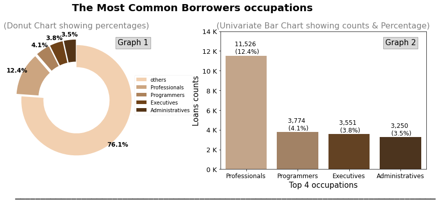

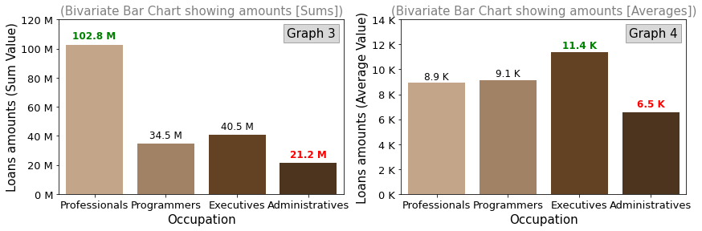

```python
plt.suptitle('The Most Common Borrowers occupations', fontsize=20,va='bottom', fontweight='bold')
plt.subplot(1, 2, 1)
plt.title('(Donut Chart showing percentages)', fontsize=16, color='grey')
plt.pie(occupation_list, startangle=90, counterclock= False, autopct='%1.1f%%',pctdistance=1.1,
        textprops={'fontsize': 12, 'fontweight':'bold'}, colors=['#f2d0b0','#cca580', '#ac825b', '#6e4218', '#543416'],
        labeldistance= 0.1, explode = (0, 0.1,0.1,0.1,0.1)  ,wedgeprops = {'width' : 0.4})
plt.xticks(rotation = 100);
plt.legend(labels=['others','Professionals', 'Programmers', 'Executives', 'Administratives'], framealpha = 0.2, bbox_to_anchor=(0.9,0.7));
plt.text(0.8,0.9, 'Graph 1', transform= plt.gca().transAxes, color='black', fontsize=15, bbox= {'facecolor': 'grey','alpha': 0.3})

plt.subplot(1, 2, 2)
plt.title('(Univariate Bar Chart showing counts & Percentage)', fontsize=16, color='grey')
sb.countplot(x= df.occupation, order= df.occupation.value_counts()[1:5].index, palette=['#cca580', '#ac825b', '#6e4218', '#543416']);
#sb.barplot(y= df.occupation.value_counts()[1:5], x= df.occupation.value_counts()[1:5].index, palette=[sb.color_palette()[i] for i in range(1,5)]);
plt.xticks([0,1,2,3],['Professionals', 'Programmers', 'Executives', 'Administratives'])
plt.ylim(0,12500)
plt.draw()
locs, labels = plt.yticks()
labels = [str(round(float(x.get_text())/1000))+' K' for x in labels]
plt.yticks(locs, labels,fontsize=13)
plt.xticks(fontsize=12)
plt.xlabel('Top 4 occupations', fontsize=15)
plt.ylabel('Loans counts', fontsize=15)
for i in np.arange(0,4):
    count = df.occupation.value_counts()[i+1]
    perc= df.occupation.value_counts(normalize=True)[i+1]
    txt=  '{:,d}'.format(count)+' \n ('+str(round(float(perc*100),1))+'%)'
    plt.text(i, count+200, txt, ha='center', size=12);
plt.text(0.8,0.9, 'Graph 2', transform= plt.gca().transAxes, color='black', fontsize=15, bbox= {'facecolor': 'grey','alpha': 0.3})
plt.text(-1,-0.2, '_'*82, transform= plt.gca().transAxes, color='black', fontsize=20)
plt.show()

plt.figure(figsize=(14,4))
plt.subplot(1,2,1)
plt.title('(Bivariate Bar Chart showing amounts [Sums])', fontsize=15, color='grey')
sb.barplot(data=df1, x='occupation', y='amount', estimator=sum, ci=None, order=ind, palette=['#cca580', '#ac825b', '#6e4218', '#543416'])
bar=0
for i in ind:
    val = df1[df1.occupation.isin([i])].amount.sum()
    txt = str(round(float(val/1e6),1))+' M'
    if bar==0:
        plt.text(bar,val+6e6, txt, fontsize=12, va='center', ha='center',color='green', fontweight='bold')
    elif bar==3:
        plt.text(bar,val+6e6, txt, fontsize=12, va='center', ha='center', color='r', fontweight='bold')
    else:
        plt.text(bar,val+6e6, txt, fontsize=12, va='center', ha='center')
    bar+=1
plt.ylim(0,1.1e8)
plt.draw()
locs, labels = plt.yticks()
labels= [str(round(float(x.get_text())*100))+' M' for x in labels]
plt.yticks(locs, labels, fontsize=13)
plt.xticks([0,1,2,3],['Professionals', 'Programmers', 'Executives', 'Administratives'],fontsize=13)
plt.ylabel('Loans amounts (Sum Value)', fontsize=15)
plt.xlabel('Occupation', fontsize=15)
plt.text(0.8,0.9, 'Graph 3', transform= plt.gca().transAxes, color='black', fontsize=15, bbox= {'facecolor': 'grey','alpha': 0.3})

plt.subplot(1,2,2)
plt.title('(Bivariate Bar Chart showing amounts [Averages])', fontsize=15, color='grey')
sb.barplot(data=df1, x='occupation', y='amount', order=ind, ci=None, palette=['#cca580', '#ac825b', '#6e4218', '#543416'])
plt.xticks([0,1,2,3],['Professionals', 'Programmers', 'Executives', 'Administratives'],fontsize=13)
plt.ylim(0,12500)
bar=0
for i in ind:
    val = df1[df1.occupation.isin([i])].amount.mean()
    txt = str(round(float(val/1e3),1))+' K'
    if bar==2:
        plt.text(bar,val+500, txt, fontsize=12, va='center', ha='center', color='green', fontweight='bold')
    elif bar==3:
        plt.text(bar,val+700, txt, fontsize=12, va='center', ha='center', color='r', fontweight='bold')
    else:
        plt.text(bar,val+500, txt, fontsize=12, va='center', ha='center')
    bar+=1
plt.draw()
locs, labels = plt.yticks()
labels= [str(round(float(x.get_text())/1000))+' K' for x in labels]
plt.yticks(locs, labels, fontsize=13)
plt.ylabel('Loans amounts (Average Value)', fontsize=15)
plt.xlabel('Occupation', fontsize=15)
plt.text(0.8,0.9, 'Graph 4', transform= plt.gca().transAxes, color='black', fontsize=15, bbox= {'facecolor': 'grey','alpha': 0.3})
plt.show()
```

# Observations :

> Graph 1&2 show that professionals are the top loaners by far (12.4%), followed by programmers.

> Graph 3 shows that total amounts loaned by professionals in these years are about (100 Million), followed by executives (40 Millions) -not programmers- and that can be explained by graph 4. it shows that executives are the hightest in terms of loans average (11.4 Thousands), while programmers are (9.1 Thousands).

## Visualization 5:

## The most common borrowers occupations through the years

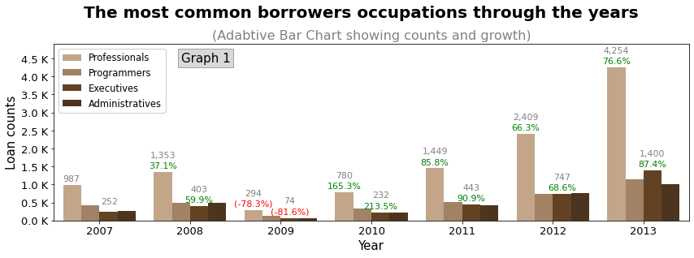

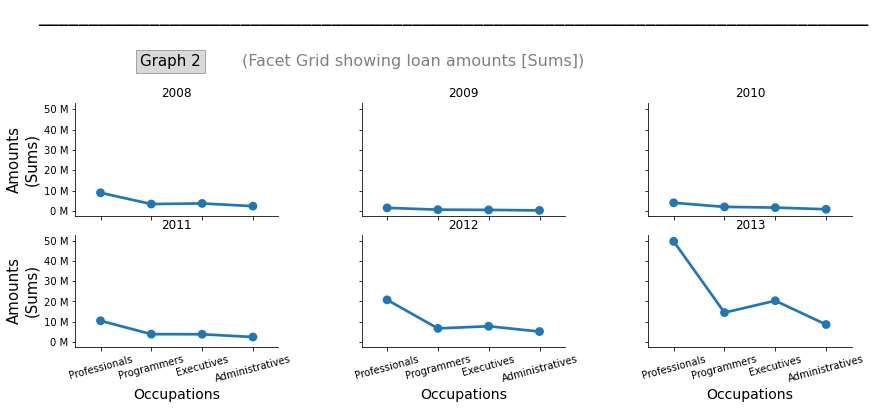

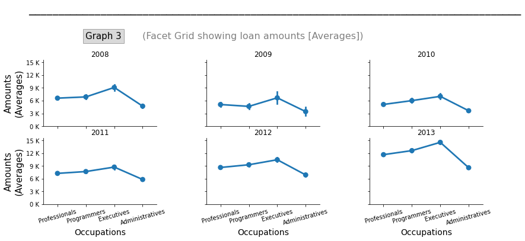

```python
plt.figure(figsize=(14,4))
sb.countplot(x= df.year, hue_order= df.occupation.value_counts()[1:5].index,hue=df.occupation
             , palette=['#cca580', '#ac825b', '#6e4218', '#543416'])
plt.draw()
locs, labels =plt.yticks()
labels = [str(round(float(x.get_text())/1000,1))+' K' for x in labels]
plt.yticks(locs,labels,size=13)
plt.xticks(size=13)
plt.xlabel('Year', size=15)
plt.ylabel('Loan counts', size=15)
plt.ylim(0,4900)
plt.title('(Adabtive Bar Chart showing counts and growth)', size=16, color='grey')
plt.suptitle('The most common borrowers occupations through the years', size=20, fontweight='bold', va='bottom')
ii = df.year.value_counts(sort=False).index
x=0
for i in df.year.value_counts(sort=False).index:
    if i != 2007:
        val1 = df[df.year.isin([i])].occupation.value_counts()['Professional']
        val11 = df[df.year.isin([ii[x-1]])].occupation.value_counts()['Professional'] *100
        perc1= round((val1/val11 *10000)-100,1)
        txt1= f'{val1:,}'
        txt11=f'{perc1:,}'+'%'
        val2 = df[df.year.isin([i])].occupation.value_counts()['Executive']
        val22 = df[df.year.isin([ii[x-1]])].occupation.value_counts()['Executive'] *100
        perc2= round((val2/val22 *10000)-100,1)
        txt2= f'{val2:,}'
        txt22= f'{perc2:,}'+'%'
        plt.text(x-.3, val1+400,txt1, size=11,color='grey', ha='center')
        plt.text(x+0.1, val2+400,txt2, size=11,color='grey', ha='center')
        if i in[2009]:
            plt.text(x-.3, val1+100,'('+txt11+')', size=11,color='r', ha='center')
            plt.text(x+0.1, val2+100,'('+txt22+')', size=11,color='r', ha='center')
        else:
            plt.text(x-.3, val1+100,txt11, size=11,color='green', ha='center')
            plt.text(x+0.1, val2+100,txt22, size=11,color='green', ha='center')
        x+=1
    elif i ==2007:
        val1 = df[df.year.isin([i])].occupation.value_counts()['Professional']
        txt= f'{val1:,}'
        plt.text(x-.4, val1+100,txt, size=11,color='grey')
        val2 = df[df.year.isin([i])].occupation.value_counts()['Executive']
        txt= f'{val2:,}'
        plt.text(x+0.02, val2+200,txt, size=11,color='grey')
        x+=1
plt.legend(labels=['Professionals', 'Programmers', 'Executives', 'Administratives'], framealpha = 1, prop={'size':11.5});
plt.text(0.2,0.9, 'Graph 1', transform= plt.gca().transAxes, color='black', fontsize=15, bbox= {'facecolor': 'grey','alpha': 0.3})
plt.show()

g=sb.FacetGrid(data=df, col='year', col_order=np.arange(2008,2014) ,col_wrap=3, sharey=True)
g.map(sb.pointplot, 'occupation', 'amount',estimator=sum,  order=df.occupation.value_counts().index[1:5])
g.set_xlabels('Occupations', size=14)
g.set_ylabels('Amounts\n(Sums)', size=15)
y_ticks= np.arange(0,51e6,10e6)
g.set(yticks=y_ticks)
g.set_yticklabels([str(round(float(y/1e6)))+' M' for y in y_ticks])
g.set_xticklabels(['Professionals', 'Programmers', 'Executives', 'Administratives'],rotation=15)
terms=np.arange(2008,2014)
c=0
for i in np.arange(0,6):
    g.axes[i].set_title(terms[c])
    c+=1
plt.gcf().set_size_inches(12.5, 4)
plt.text(-2,2.5,'(Facet Grid showing loan amounts [Sums])', size=16,color='grey',transform= plt.gca().transAxes)
plt.text(-2.5,2.5, 'Graph 2', transform= plt.gca().transAxes, color='black', fontsize=15, bbox= {'facecolor': 'grey','alpha': 0.3})
plt.text(-3,2.9, '_'*82, transform= plt.gca().transAxes, color='black', fontsize=20)

g=sb.FacetGrid(data=df, col='year', col_order=np.arange(2008,2014) ,col_wrap=3, sharey=True)
g.map(sb.pointplot, 'occupation', 'amount',  order=df.occupation.value_counts().index[1:5])
g.set_xlabels('Occupations', size=14)
g.set_ylabels('Amounts\n(Averages)', size=15)
y_ticks= np.arange(0,15.1e3,3e3)
g.set(yticks=y_ticks)
g.set_yticklabels([str(round(float(y/1e3)))+' K' for y in y_ticks])
g.set_xticklabels(['Professionals', 'Programmers', 'Executives', 'Administratives'],rotation=15)

terms=np.arange(2008,2014)
c=0
for i in np.arange(0,6):
    g.axes[i].set_title(terms[c])
    c+=1
plt.text(-2,2.5,'(Facet Grid showing loan amounts [Averages])', size=16,color='grey',transform= plt.gca().transAxes)
plt.text(-2.5,2.5, 'Graph 3', transform= plt.gca().transAxes, color='black', fontsize=15, bbox= {'facecolor': 'grey','alpha': 0.3})
plt.text(-3,2.9, '_'*82, transform= plt.gca().transAxes, color='black', fontsize=20)
plt.gcf().set_size_inches(12.5, 4)
```

# Observations :

> Graph 1: shows increased loan counts among professionals in comparison with others, this might indicate the presence of a suitable package or promotional effort done to this specific category, also executives show the sharpest growth among all other professions, no doubt that preparing a suitable package for this category will drastically increase their loan counts on the long run.

> Graph 2: we observe a sharp increase in professional loan-sums (especially in the last 3 years) and that can be explained by the gradual increase in their share in loan counts as seen in graph 1.

> Graph 3: we observe that loan values (in average) for executives seems to be the hightest in all years, so more effort in this category will increase total loan-sums. no other note worth mentioning here except that the loans averages increased through the last 3 years. this insight will be invistigated later.

## Visualization 6:

## The most and the least common borrowers states

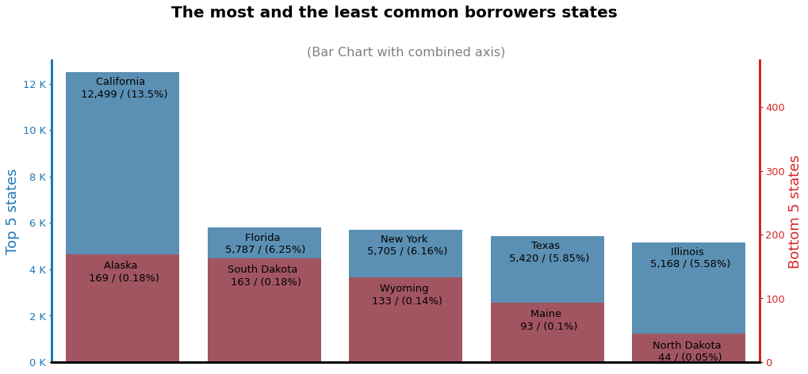

```python
plt.figure(figsize=(16,7))
plt.suptitle('The most and the least common borrowers states', fontsize=20, fontweight='bold',va='bottom')
plt.title('(Bar Chart with combined axis)', fontsize=16, color='grey')

ax1= sb.barplot(x=states_data.index[0:5], y=states_data[0:5], color=color, alpha=0.8,label='Top 5 Carriers')
plt.draw()
locs, labels = plt.yticks()
labels = [str(round(float(x.get_text())/1000))+ ' K' for x in labels]
plt.yticks(locs, labels, color=color, fontsize=13)
plt.ylim(0,13000)
plt.ylabel('Top 5 states', color=color, fontsize=18)
for i in range(0,5):
    count= states_data[i]
    perc= df.state.value_counts(normalize=True)[i]
    txt= states_dict[states_data.index[i]] + ' \n ' +str(f'{count:,}')+' / ('+str(f'{round(float(perc*100),2):,}')+'%)'
    plt.text(i, count-200, txt, va='top', ha='center', fontsize=13)
ax1.spines['top'].set_visible(False)

ax2= ax1.twinx()
ax2= sb.barplot(x=states_data.index[-5:], y=states_data[-5:], color=alt_color, alpha=0.7, label='Bottom 5 Carriers')
plt.yticks(color=alt_color, fontsize=13)
plt.ylim(0,df.state.value_counts()[-5:].max()*2.8)
plt.ylabel('Bottom 5 states', color=alt_color, fontsize=18)
plt.xticks([])
for i in range(-1,-6, -1):
    count= states_data[i]
    perc= df.state.value_counts(normalize=True)[i]
    txt= states_dict[states_data.index[i]] + ' \n ' +str(f'{count:,}')+' / ('+str(f'{round(float(perc*100),2):,}')+'%)'
    plt.text(i+5, count-10, txt, va='top', ha='center', fontsize=13)
ax2.spines['right'].set_linewidth(3)
ax2.spines['right'].set_color(alt_color)
ax2.spines['bottom'].set_linewidth(3)
ax2.spines['top'].set_visible(False)
ax2.spines['left'].set_linewidth(3)
ax2.spines['left'].set_color(color)
plt.show();
```

# Observations :

> Graph 1 shows that California state is the most common by far (13.5 %, 12,499 Loans) followed by Florida, New York, Texas and Illinois (the last 4 have close figures), while the least common is north dakota with (0.05%, 44 Loans) followed by Maine, Wyoming, South Dakota, Alaska.

## Visualization 7:

## Loan amounts for the top and bottom 5 states

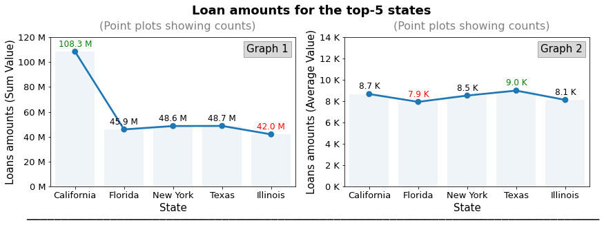

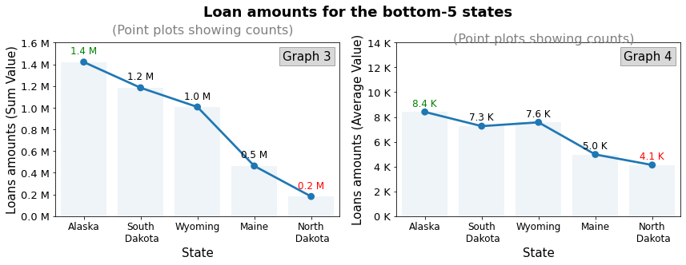

```python
plt.figure(figsize=(14,4))
plt.suptitle('Loan amounts for the top-5 states', fontsize=18, fontweight='bold',va='bottom')
plt.subplot(1,2,1)
sb.pointplot(data=df1, x='state', y='amount', estimator=sum, order=ind1)
sb.barplot(data=df1, x='state', y='amount', estimator=sum, ci=None, order=ind1, alpha=0.08, color=color)
bar=0
for i in ind1:
    val = df1[df1.state.isin([i])].amount.sum()
    txt = str(round(float(val/1e6),1))+' M'
    if bar==0:
        plt.text(bar,val+6e6, txt, fontsize=12, va='center', ha='center',color='green')
    elif bar==4:
        plt.text(bar,val+6e6, txt, fontsize=12, va='center', ha='center', color='r')
    else:
        plt.text(bar,val+6e6, txt, fontsize=12, va='center', ha='center')
    bar+=1
plt.ylim(0,1.1e8)
plt.draw()
locs, labels = plt.yticks()
labels= [str(round(float(x.get_text())*100))+' M' for x in labels]
plt.yticks(locs, labels, fontsize=13)
plt.xticks([0,1,2,3,4],['California','Florida', 'New York','Texas','Illinois'],fontsize=13)
plt.ylabel('Loans amounts (Sum Value)', fontsize=15)
plt.xlabel('State', fontsize=15)
plt.text(0.8,0.9, 'Graph 1', transform= plt.gca().transAxes, color='black', fontsize=15, bbox= {'facecolor': 'grey','alpha': 0.3})
plt.text(0.2,1.05, '(Point plots showing counts)', transform= plt.gca().transAxes, color='grey', fontsize=16)

plt.subplot(1,2,2)
sb.pointplot(data=df1, x='state', y='amount', ci=None, order=ind1)
sb.barplot(data=df1, x='state', y='amount', order=ind1, ci=None, alpha=0.08, color=color)
plt.xticks([0,1,2,3,4],['California','Florida', 'New York','Texas','Illinois'],fontsize=13)
plt.ylim(0,12500)
plt.draw()
locs, labels = plt.yticks()
labels= [str(round(float(x.get_text())/1000))+' K' for x in labels]
plt.yticks(locs, labels, fontsize=13)
bar=0
for i in ind1:
    val = df1[df1.state.isin([i])].amount.mean()
    txt = str(round(float(val/1e3),1))+' K'
    if bar==3:
        plt.text(bar,val+700, txt, fontsize=12, va='center', ha='center', color='green')
    elif bar==1:
        plt.text(bar,val+700, txt, fontsize=12, va='center', ha='center', color='r')
    else:
        plt.text(bar,val+700, txt, fontsize=12, va='center', ha='center')
    bar+=1
plt.ylabel('Loans amounts (Average Value)', fontsize=15)
plt.xlabel('State', fontsize=15)
plt.text(0.8,0.9, 'Graph 2', transform= plt.gca().transAxes, color='black', fontsize=15, bbox= {'facecolor': 'grey','alpha': 0.3})
plt.text(0.2,1.05, '(Point plots showing counts)', transform= plt.gca().transAxes, color='grey', fontsize=16)
plt.text(-1.3,-0.2, '_'*82, transform= plt.gca().transAxes, color='black', fontsize=20)
plt.show

plt.figure(figsize=(14,4))
plt.suptitle('Loan amounts for the bottom-5 states', fontsize=18, fontweight='bold',va='bottom')
plt.subplot(1,2,1)
sb.pointplot(data=df2, x='state', y='amount', estimator=sum,ci=None, order=ind2)
sb.barplot(data=df2, x='state', y='amount', estimator=sum, ci=None, order=ind2, alpha=0.08, color=color)
bar=0
for i in ind2:
    val = df2[df2.state.isin([i])].amount.sum()
    txt = str(round(float(val/1e6),1))+' M'
    if bar==0:
        plt.text(bar,val+1e5, txt, fontsize=12, va='center', ha='center',color='green')
    elif bar==4:
        plt.text(bar,val+1e5, txt, fontsize=12, va='center', ha='center', color='r')
    else:
        plt.text(bar,val+1e5, txt, fontsize=12, va='center', ha='center')
    bar+=1
plt.draw()
locs, labels = plt.yticks()
labels= [str(float(x.get_text()))+' M' for x in labels]
plt.yticks(locs, labels, fontsize=13)
plt.xticks([0,1,2,3,4],['Alaska','South\n Dakota','Wyoming','Maine','North\n Dakota'],fontsize=12)
plt.ylabel('Loans amounts (Sum Value)', fontsize=15)
plt.xlabel('State', fontsize=15)
plt.text(0.8,0.9, 'Graph 3', transform= plt.gca().transAxes, color='black', fontsize=15, bbox= {'facecolor': 'grey','alpha': 0.3})
plt.text(0.2,1.05, '(Point plots showing counts)', transform= plt.gca().transAxes, color='grey', fontsize=16)

plt.subplot(1,2,2)
sb.pointplot(data=df2, x='state', y='amount', ci=None, order=ind2)
sb.barplot(data=df2, x='state', y='amount', order=ind2, ci=None, alpha=0.08, color=color)
plt.xticks([0,1,2,3,4],['Alaska','South\n Dakota','Wyoming','Maine','North\n Dakota'],fontsize=12)
plt.ylim(0,12500)
plt.draw()
locs, labels = plt.yticks()
labels= [str(round(float(x.get_text())/1000))+' K' for x in labels]
plt.yticks(locs, labels, fontsize=13)
bar=0
for i in ind2:
    val = df2[df2.state.isin([i])].amount.mean()
    txt = str(round(float(val/1e3),1))+' K'
    if bar==0:
        plt.text(bar,val+700, txt, fontsize=12, va='center', ha='center', color='green')
    elif bar==4:
        plt.text(bar,val+700, txt, fontsize=12, va='center', ha='center', color='r')
    else:
        plt.text(bar,val+700, txt, fontsize=12, va='center', ha='center')
    bar+=1
plt.ylabel('Loans amounts (Average Value)', fontsize=15)
plt.xlabel('State', fontsize=15)
plt.text(0.8,0.9, 'Graph 4', transform= plt.gca().transAxes, color='black', fontsize=15, bbox= {'facecolor': 'grey','alpha': 0.3})
plt.text(0.2,1, '(Point plots showing counts)', transform= plt.gca().transAxes, color='grey', fontsize=16)
plt.show()
```

# Observations :

> Graph 3&4 show that among the bottom-5 states, alaska contribute the most in cases of loan-sums by value of (1.4 Millions) followed by south-dakota with value of (1.2 Millions), also, alaska has the hightest loan-average by value of (8.4 Thousands) followed by wyoming by the value of (7.6 Thousands).

## Visualization 8:

## States comparison in terms of loan-amounts and loan-terms

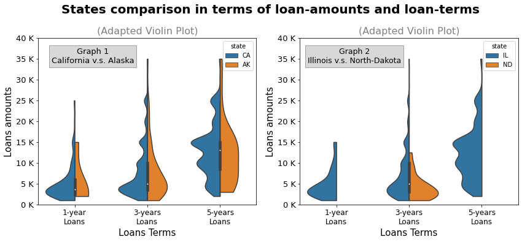

```python
plt.figure(figsize=(14,5))
plt.subplot(1,2,1)
plt.suptitle('States comparison in terms of loan-amounts and loan-terms', fontsize=20, fontweight='bold',va='bottom')
plt.title('(Adapted Violin Plot)', fontsize=16, color='grey')
sb.violinplot(data=df1, y='amount', x='term', hue='state', split=True, cut=0)
plt.xticks([0,1,2],['1-year\nLoans','3-years\nLoans','5-years\nLoans'],size=12)
plt.ylim(0,35500)
plt.draw()
locs, labels = plt.yticks()
labels= [str(round(float(x.get_text())/1000))+' K' for x in labels]
plt.yticks(locs, labels, fontsize=13)
plt.ylabel('Loans amounts', fontsize=15)
plt.xlabel('Loans Terms', fontsize=15)
plt.text(0.25,0.85, 'Graph 1\nCalifornia v.s. Alaska', transform= plt.gca().transAxes, color='black', fontsize=13,ha='center', bbox= {'facecolor': 'grey','alpha': 0.3})

plt.subplot(1,2,2)
plt.title('(Adapted Violin Plot)', fontsize=16, color='grey')
g=sb.violinplot(data=df2, y='amount', x='term', hue='state',labels=['hhj','jj'], split=True, cut=0)
plt.xticks([0,1,2],['1-year\nLoans','3-years\nLoans','5-years\nLoans'],size=12)
plt.ylim(0,35500)
plt.draw()
locs, labels = plt.yticks()
labels= [str(round(float(x.get_text())/1000))+' K' for x in labels]
plt.yticks(locs, labels, fontsize=13)
plt.ylabel('Loans amounts', fontsize=15)
plt.xlabel('Loans Terms', fontsize=15)
plt.text(0.25,0.85, 'Graph 2\nIllinois v.s. North-Dakota', transform= plt.gca().transAxes, color='black', fontsize=12.5,ha='center', bbox= {'facecolor': 'grey','alpha': 0.3})
plt.show()
```

# Observations

> Graph 1 shows that the starting loan values in alaska state is slightly higher than that of california, in 1-year loans the least loan amount in alaska is 2k versus 1k in california. and in 5-years loans the least loan amount in alaska is 3k versus 2k in california. however, in 1-year loans we find that the hightest loan amount in alaska is 15k verus 25k in california. also it seems that loans values in alaska is more uniformly distributed unlike in california which shows a little segmentation around 5k,10k,15k (might indicate the presence of default pre-determined packages).

> Graph 2 shows that only 3-years loans are available in north-dakota, the hightest loan value in north-dakota is 12.5k versus 35k in illinois. also the curve of illinois shows a little segmentation (resemble that of california).

## Visualization 9:

## Loans amounts distribution (over-all view)

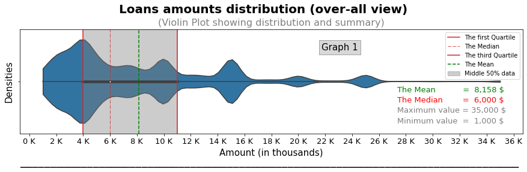

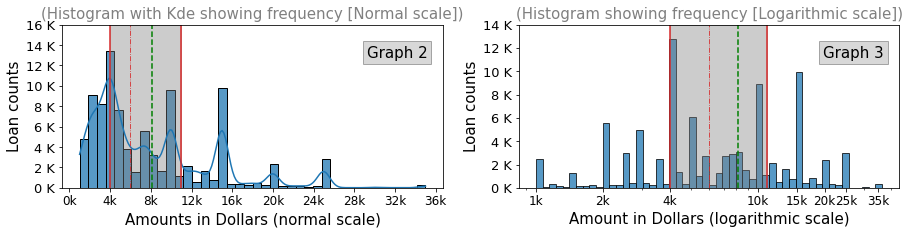

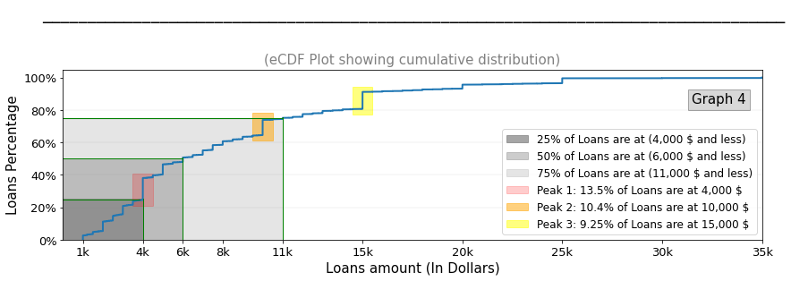

```python
plt.figure(figsize=(15,3.2))
plt.suptitle('Loans amounts distribution (over-all view)', size=20, va='bottom', fontweight='bold')
plt.title('(Violin Plot showing distribution and summary)', fontsize=16, color='grey')
sb.violinplot(x=df.amount, cut=0,alpha=0.75)
ticks= np.arange(0,36001,2000)
tick_names = [str(round(float(x/1000)))+' K' for x in ticks]
plt.xticks(ticks, tick_names, fontsize=13)
plt.axvline(values_firstq, color= alt_color, label='The first Quartile')
plt.axvline(values_secondq, color= alt_color, ls=('-.'), label='The Median', lw=0.8)
plt.axvline(values_thirdq, color= alt_color, label='The third Quartile')
plt.axvline(amount_mean, color= 'green', ls='--', label='The Mean')
plt.axvspan(values_firstq,values_thirdq, color='grey', alpha=0.4,label='Middle 50% data')
plt.text(0.75, 0.2, 'Maximum value = '+str(f'{df.amount.max():,}')+ ' $', transform= plt.gca().transAxes, color='grey', fontsize=13)
plt.text(0.75, 0.1, 'Minimum value  =  '+str(f'{df.amount.min():,}')+ ' $', transform= plt.gca().transAxes, color='grey', fontsize=13)
plt.text(0.75, 0.4, 'The Mean           =  '+str(f'{round(amount_mean):,}')+ ' $', transform= plt.gca().transAxes, color='green', fontsize=13)
plt.text(0.75, 0.3, 'The Median        =  '+str(f'{round(values_secondq):,}')+ ' $', transform= plt.gca().transAxes, color='r', fontsize=13)
plt.legend(prop={'size':10}, frameon=True)
plt.xlabel('Amount (in thousands)', fontsize=15)
plt.ylabel('Densities', fontsize=15)
plt.text(0.6,0.8, 'Graph 1', transform= plt.gca().transAxes, color='black', fontsize=15, bbox= {'facecolor': 'grey','alpha': 0.3})
plt.text(0,-0.3, '_'*82, transform= plt.gca().transAxes, color='black', fontsize=20)
plt.show

plt.figure(figsize=(15,3))
plt.subplot(1, 2, 1) # using normal scale
sb.histplot(df.amount, bins=40, edgecolor="k", linewidth=1, kde=True, color=color, alpha=0.75)
ticks= np.arange(0,36001,4000)
tick_names = [str(round(float(i/1000)))+'k' for i in ticks]
plt.xticks(ticks, tick_names, fontsize=12)
plt.draw()
locs,labels = plt.yticks()
labels = [str(round(float(x.get_text())/1000))+ ' K' for x in labels]
plt.yticks(locs, labels, fontsize=13)
plt.xlabel('Amounts in Dollars (normal scale)', fontsize=15)
plt.ylabel('Loan counts', fontsize=15)
plt.title('(Histogram with Kde showing frequency [Normal scale])', fontsize=15, color='grey')
plt.text(0.80,0.8, 'Graph 2', transform= plt.gca().transAxes, color='black', fontsize=15, bbox= {'facecolor': 'grey','alpha': 0.3})
plt.axvline(values_firstq, color= alt_color, label='The first Quartile')
plt.axvline(values_secondq, color= alt_color, ls=('-.'), label='The Median', lw=0.8)
plt.axvline(values_thirdq, color= alt_color, label='The third Quartile')
plt.axvline(amount_mean, color= 'green', ls='--', label='The Mean')
plt.axvspan(values_firstq,values_thirdq, color='grey', alpha=0.4,label='Middle 50% data')

plt.subplot(1, 2, 2) # using logarithmic scale
bins = 10 ** np.arange(np.log10(df.amount.min()), np.log10(df.amount.max())+0.03, 0.03)
plt.hist(df.amount, bins= bins, edgecolor="k", linewidth=1,alpha=0.75);
plt.xscale('log')
ticks = [1000, 2000, 4000, 10000, 15000, 20000, 25000, 35000]
ticks_names = [str(round(float(i/1000)))+'k' for i in ticks]
plt.xticks(ticks, ticks_names, fontsize=12);
plt.draw()
locs,labels = plt.yticks()
labels = [str(round(float(x.get_text())/1000))+ ' K' for x in labels]
plt.yticks(locs, labels, fontsize=13)
plt.xlabel('Amount in Dollars (logarithmic scale)', fontsize=15)
plt.ylabel('Loan counts', fontsize=15)
plt.title('(Histogram showing frequency [Logarithmic scale])', fontsize=15, color='grey')
plt.text(0.80,0.8, 'Graph 3', transform= plt.gca().transAxes, color='black', fontsize=15, bbox= {'facecolor': 'grey','alpha': 0.3})
plt.axvline(values_firstq, color= alt_color, label='The first Quartile')
plt.axvline(values_secondq, color= alt_color, ls=('-.'), label='The Median', lw=0.8)
plt.axvline(values_thirdq, color= alt_color, label='The third Quartile')
plt.axvline(amount_mean, color= 'green', ls='--', label='The Mean')
plt.axvspan(values_firstq,values_thirdq, color='grey', alpha=0.4,label='Middle 50% data')
plt.show()

plt.figure(figsize=(14,3.5))
plt.title('(eCDF Plot showing cumulative distribution)', fontsize=15, color='grey')
sb.ecdfplot(data=df, x='amount', lw=2)
plt.axhline(0.2, ls='-', lw=0.1, color='grey')
plt.axhline(0.4, ls='-', lw=0.1, color='grey')
plt.axhline(0.6, ls='-', lw=0.1, color='grey')
plt.axhline(0.8, ls='-', lw=0.1, color='grey')
plt.axhline(0.25, ls='-', lw=1, color='g', xmax=0.11)
plt.axhline(0.5, ls='-', lw=1, color='g', xmax=0.17)
plt.axhline(0.75, ls='-', lw=1, color='g', xmax=0.315)
plt.axvline(4000, ls='-', lw=1, color='g', ymax=0.24)
plt.axvline(6000, ls='-', lw=1, color='g', ymax=0.48)
plt.axvline(11000, ls='-', lw=1, color='g', ymax=0.72)
plt.xlim(0,30001)
plt.axvspan(0,4000,color='grey', alpha=0.7, ymax=0.24, label='25% of Loans are at ('+f'{round(np.quantile(df.amount, .25)):,}'+ ' $ and less)')
plt.axvspan(0,6000,color='grey', alpha=0.4, ymax=0.478, label='50% of Loans are at ('+f'{round(np.quantile(df.amount, .5)):,}'+ ' $ and less)')
plt.axvspan(0,11000,color='grey', alpha=0.2, ymax=0.71, label='75% of Loans are at ('+f'{round(np.quantile(df.amount, .75)):,}'+ ' $ and less)')
plt.legend(loc=4)
plt.draw()
locs, labels = plt.yticks()
labels= [str(round(float(x.get_text())*100))+'%' for x in labels]
plt.yticks(locs, labels, fontsize=13)
ticks=[1000,4000,6000,8000,11000,15000,20000,25000,30000,35000]
labels=[str(round(x/1000)) +'k' for x in ticks]
plt.xticks(ticks, labels, fontsize=13)
plt.ylim(0,1.05)
plt.ylabel('Loans Percentage', fontsize=15)
plt.xlabel('Loans amount (In Dollars)', fontsize=15);
plt.text(0.9,0.8, 'Graph 4', transform= plt.gca().transAxes, color='black', fontsize=15, bbox= {'facecolor': 'grey','alpha': 0.3})
rect1 = Rectangle((3500,0.21), 1000, 0.2, alpha=0.2, fill=True, color='r', label='Peak 1: 13.5% of Loans are at 4,000 $')
rect2 = Rectangle((9500,0.61), 1000, 0.17, alpha=0.5, fill=True, color='orange', label='Peak 2: 10.4% of Loans are at 10,000 $')
rect3 = Rectangle((14500,0.77), 1000, 0.17, alpha=0.5, fill=True, color='yellow', label='Peak 3: 9.25% of Loans are at 15,000 $')
plt.gca().add_patch(rect1)
plt.gca().add_patch(rect2)
plt.gca().add_patch(rect3)
plt.legend(prop={'size':12}, loc=4)
plt.text(-0.03,1.3, '_'*82, transform= plt.gca().transAxes, color='black', fontsize=20)
plt.show()
```

# Observations :

> Graph 1 show the loans amount distribution in which we observe a wide range of amounts from (1k to 35k) with 8.15k as the mean of all amounts, 50 % of loan amounts are below 6k.

> Graph 2&3 show several peaks at (0.5k) intervals starting from (1k), the most prominant peaks are at (4k, 10k, 15k) which might be explained by the prescence of a certain default loan amounts or default package that lots of borrowers preferred (ex. 4k Loans), that can be confirmed statistically.

> Graph 4 shows that loan amounts of (4k,10k,15k) represent about the third of all loans (33%).also, 50% of loans are of values 6K and less, while 75% of loans are of values 11k and less.

## Visualization 10:

## Loans amounts distribution (over the years)

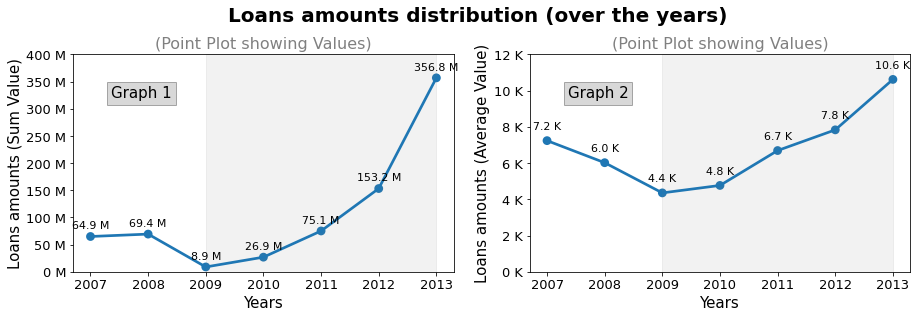

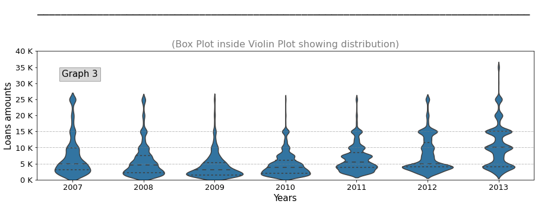

```python
plt.figure(figsize=(15,4))
plt.suptitle('Loans amounts distribution (over the years)', size=20, fontweight='bold', va='bottom')

plt.subplot(1,2,1)
plt.title('(Point Plot showing Values)', size=16, color='grey')
sb.pointplot(data=df, x='year', y='amount', estimator=sum)
plt.ylim(0,4e8)
plt.draw()
locs, labels = plt.yticks()
labels= [str(round(float(x.get_text())*100))+' M' for x in labels]
plt.yticks(locs, labels, fontsize=13)
plt.xticks(fontsize=13)
plt.ylabel('Loans amounts (Sum Value)', fontsize=15)
plt.xlabel('Years', fontsize=15)
bar=0
for i in range(2007,2014):
    val = df[df.year.isin([i])].amount.sum()
    txt = str(round(float(val/1e6),1))+' M'
    plt.text(bar,val+20e6, txt, fontsize=11, va='center', ha='center')
    bar+=1
plt.axvspan(2,6,color='grey', alpha=0.1)
plt.text(0.1,0.8, 'Graph 1', transform= plt.gca().transAxes, color='black', fontsize=15, bbox= {'facecolor': 'grey','alpha': 0.3})

plt.subplot(1,2,2)
plt.title('(Point Plot showing Values)', size=16, color='grey')
sb.pointplot(data=df, x='year', y='amount', ci=None)
plt.ylim(0,12000)
plt.draw()
locs, labels = plt.yticks()
labels= [str(round(float(x.get_text())/1000))+' K' for x in labels]
plt.yticks(locs, labels, fontsize=13)
plt.xticks(fontsize=13)
plt.ylabel('Loans amounts (Average Value)', fontsize=15)
plt.xlabel('Years', fontsize=15)
bar=0
for i in range(2007,2014):
    val = df[df.year.isin([i])].amount.mean()
    txt = str(round(float(val/1e3),1))+' K'
    plt.text(bar,val+800, txt, fontsize=11, va='center', ha='center')
    bar+=1
plt.axvspan(2,6,color='grey', alpha=0.1)
plt.text(0.1,0.8, 'Graph 2', transform= plt.gca().transAxes, color='black', fontsize=15, bbox= {'facecolor': 'grey','alpha': 0.3})
plt.show()

plt.figure(figsize=(15,4))
plt.title('(Box Plot inside Violin Plot showing distribution)', size=16, color='grey')
sb.violinplot(data=df, x= 'year', y='amount', inner='quartile',color=color);
plt.ylim(0,40000)
plt.draw()
locs, labels = plt.yticks()
labels= [str(round(float(x.get_text())/1000))+' K' for x in labels]
plt.yticks(locs, labels, fontsize=13)
plt.xticks(fontsize=13)
plt.axhline(5000,color='grey', ls='-.', linewidth=0.5)
plt.axhline(10000,color='grey', ls='-.', linewidth=0.5)
plt.axhline(15000,color='grey', ls='-.', linewidth=0.5)
plt.ylabel('Loans amounts', fontsize=15)
plt.xlabel('Years', fontsize=15)
plt.text(0.05,0.8, 'Graph 3', transform= plt.gca().transAxes, color='black', fontsize=15, bbox= {'facecolor': 'grey','alpha': 0.3})
plt.text(0,1.3, '_'*82, transform= plt.gca().transAxes, color='black', fontsize=20)
plt.show()
```

# Observations :

> Graph 1&2 show higher demands on higher loan amounts through the years starting from (2009), the average loans amounts increased from 4.4k to 10.6k (140% growth) in 5 years which might indicate inflation.

## Visualization 11:

## Loans apr distribution (over-all view)

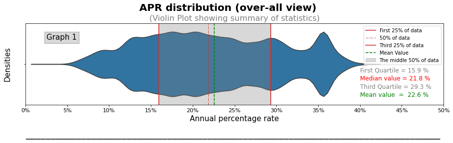

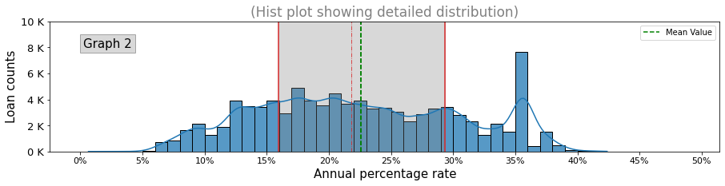

```python
plt.figure(figsize=(15,3))
plt.suptitle('APR distribution (over-all view)', size=20, fontweight='bold', va='bottom')
plt.title('(Violin Plot showing summary of statistics)', fontsize=16, color='grey')
sb.violinplot(x=df.apr, cut=0, inner=None,alpha=0.75)
plt.legend(['First Quartile','The Median','Third Quartile'])
plt.ylabel('Densities', fontsize=15)
plt.xlabel('Annual percentage rate', fontsize=15)
plt.xlim(0,0.5)
plt.text(0.8, 0.3, 'Median value = '+str(f'{round(apr_median*100,1)}')+ ' %', transform= plt.gca().transAxes, color='r', fontsize=12)
plt.text(0.8, 0.1, 'Mean value  =  '+str(f'{round(df.apr.mean()*100,1)}')+ ' %', transform= plt.gca().transAxes, color='green', fontsize=12)
plt.text(0.8, 0.4, 'First Quartile = '+str(f'{round(apr_aq*100,1)}')+ ' %', transform= plt.gca().transAxes, color='grey', fontsize=12)
plt.text(0.8, 0.2, 'Third Quartile = '+str(f'{round(apr_bq*100,1)}')+ ' %', transform= plt.gca().transAxes, color='grey', fontsize=12)
plt.axvline(apr_aq, color= alt_color, label='First 25% of data')
plt.axvline(apr_median, color= alt_color, ls=('-.'), lw=0.8, label='50% of data')
plt.axvline(apr_bq, color= alt_color, label='Third 25% of data')
plt.axvline(apr_mean, color= 'green', ls='--', label='Mean Value')
plt.axvspan(apr_aq,apr_bq, color='grey', alpha=0.3, label='The middle 50% of data')
ticks=np.arange(0,0.55,0.05)
tick_names = [str(round(x*100))+'%' for x in ticks]
plt.xticks(ticks, tick_names, fontsize=11)
plt.yticks([0],[0], size=28, color='white')
plt.legend()
plt.text(0.05,0.8, 'Graph 1', transform= plt.gca().transAxes, color='black', fontsize=15, bbox= {'facecolor': 'grey','alpha': 0.3})
plt.text(0,-0.4, '_'*82, transform= plt.gca().transAxes, color='black', fontsize=20)
plt.show()

plt.figure(figsize=(15,3))
plt.title('(Hist plot showing detailed distribution)', fontsize=17, color='grey')
bins= np.arange(0,0.5,0.01)
sb.histplot(df.apr, bins = bins, kde=True,alpha=0.75)
plt.axvline(apr_mean, color='green', label='Mean Value',ls='--')
plt.ylabel('Loan counts', fontsize=15)
plt.xlabel('Annual percentage rate', fontsize=15)
plt.draw()
locs, labels =plt.yticks()
labels = [str(round(float(x.get_text())/1000))+ ' K' for x in labels]
plt.yticks(locs, labels, fontsize=13)
plt.xticks(ticks, tick_names, fontsize=11)
plt.legend()
plt.text(0.05,0.8, 'Graph 2', transform= plt.gca().transAxes, color='black', fontsize=15, bbox= {'facecolor': 'grey','alpha': 0.3})
plt.axvline(apr_aq, color= alt_color, label='First 25% of data')
plt.axvline(apr_median, color= alt_color, ls=('-.'), lw=0.8, label='50% of data')
plt.axvline(apr_bq, color= alt_color, label='Third 25% of data')
plt.axvline(apr_mean, color= 'green', ls='--', label='Mean Value')
plt.axvspan(apr_aq,apr_bq, color='grey', alpha=0.3, label='The middle 50% of data')
plt.show()
```

# Note :

> A.P.R is the acronym of [Annual Percentage Rate] which refers to the total cost of the borrowing for a year. Importantly, it includes the standard fees and interest the loaner has to pay.

# Observations :

> Graph 1&2 show that the annual rate values are of range (0.6% to 42.4%). the most frequent loan annual rate is (35.8%) and that value represent around 4% of all loans. half the loanes are below (21.8%). the mean of all loanes rates is (22.6%).

## Visualization 12:

## Loans apr through years, and among top borrowers occupations and states

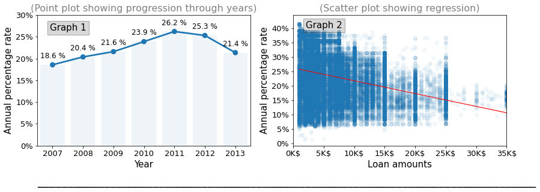

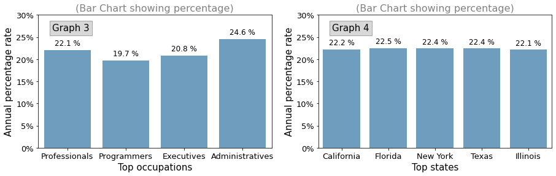

```python
plt.figure(figsize=(14,4))
plt.subplot(1,2,1)
sb.pointplot(data=df, x='year', y='apr', ci=None)
sb.barplot(data=df, x='year', y='apr', ci=None, alpha=0.08, color=color)
plt.ylim(0,.3)
ticks=np.arange(0,0.35,0.05)
tick_names = [str(round(x*100))+'%' for x in ticks]
plt.yticks(ticks, tick_names, fontsize=13)
plt.xticks(fontsize=13)
bar=0
for i in range(2007,2014):
    val= df[df.year.isin([i])].apr.mean()
    txt= str(round(val*100,1))+' %'
    plt.text(bar, val+0.02, txt, va='center', ha='center', size=12)
    bar+=1
plt.xlabel('Year', fontsize=15)
plt.ylabel('Annual percentage rate', fontsize=15)
plt.text(0.06,0.88, 'Graph 1', transform= plt.gca().transAxes, color='black', fontsize=15, bbox= {'facecolor': 'grey','alpha': 0.3})
plt.title('(Point plot showing progression through years)', color='grey', size=16)

plt.subplot(1,2,2)
sb.regplot(data= df_samples, x='amount', y='apr', scatter_kws={'alpha': 0.05},line_kws={'color': 'r', 'lw':1})
ticks=np.arange(0,0.41,0.05)
tick_names = [str(round(x*100))+'%' for x in ticks]
plt.yticks(ticks, tick_names, fontsize=13)
plt.draw()
locs, labels =plt.xticks()
labels = [str(round(float(x.get_text())/1000))+ 'K$' for x in labels]
plt.xticks(locs, labels, fontsize=13)
plt.text(0.06,0.9, 'Graph 2', transform= plt.gca().transAxes, color='black', fontsize=15, bbox= {'facecolor': 'grey','alpha': 0.3})
plt.xlabel('Loan amounts', fontsize=15)
plt.ylabel('Annual percentage rate', fontsize=15)
plt.title('(Scatter plot showing regression)', color='grey', size=16)
plt.text(-1.2,-0.3, '_'*82, transform= plt.gca().transAxes, color='black', fontsize=20)
plt.show()

plt.figure(figsize=(15,4))
plt.subplot(1,2,1)
color=sb.color_palette()[0]
sb.barplot(data=df, x='occupation', y='apr', ci=None, order=df.occupation.value_counts().index[1:5], color=color, alpha=0.7)
plt.xticks([0,1,2,3],['Professionals', 'Programmers', 'Executives', 'Administratives'],fontsize=13)
plt.ylim(0,.3)
ticks=np.arange(0,0.35,0.05)
tick_names = [str(round(x*100))+'%' for x in ticks]
plt.yticks(ticks, tick_names, fontsize=13)
bar=0
for i in df.occupation.value_counts().index[1:5]:
    val= df[df.occupation.isin([i])].apr.mean()
    txt= str(round(val*100,1))+' %'
    plt.text(bar, val+0.015, txt, va='center', ha='center', size=12)
    bar+=1
plt.xlabel('Top occupations', fontsize=15)
plt.ylabel('Annual percentage rate', fontsize=15)
plt.text(0.06,0.88, 'Graph 3', transform= plt.gca().transAxes, color='black', fontsize=15, bbox= {'facecolor': 'grey','alpha': 0.3})
plt.title('(Bar Chart showing percentage)', color='grey', size=16)

plt.subplot(1,2,2)
sb.barplot(data=df, x='state', y='apr', ci=None, order=df.state.value_counts().index[0:5], alpha=0.7, color=color)
plt.xticks([0,1,2,3,4],['California','Florida', 'New York','Texas','Illinois'],fontsize=13)
plt.ylim(0,.3)
ticks=np.arange(0,0.35,0.05)
tick_names = [str(round(x*100))+'%' for x in ticks]
plt.yticks(ticks, tick_names, fontsize=13)
bar=0
for i in df.state.value_counts().index[0:5]:
    val= df[df.state.isin([i])].apr.mean()
    txt= str(round(val*100,1))+' %'
    plt.text(bar, val+0.015, txt, va='center', ha='center', size=12)
    bar+=1
plt.xlabel('Top states', fontsize=15)
plt.ylabel('Annual percentage rate', fontsize=15)
plt.text(0.06,0.88, 'Graph 4', transform= plt.gca().transAxes, color='black', fontsize=15, bbox= {'facecolor': 'grey','alpha': 0.3})
plt.title('(Bar Chart showing percentage)', color='grey', size=16)
plt.show()
```

# Notes :

# Observations :

> Graph 1 shows an increased a.p.r through the years till year (2011), followed by a slight decrease.

> Graph 2 shows that a.p.r is inversely proportional to loan amounts, it means that the higher the value of loan the less a.p.r value connected with the loan, wich is really interesting.

> Graph 4 shows that the a.p.r values are very close among the top-5 states.

## Visualization 13:

## Loans terms distribution (over-all view)

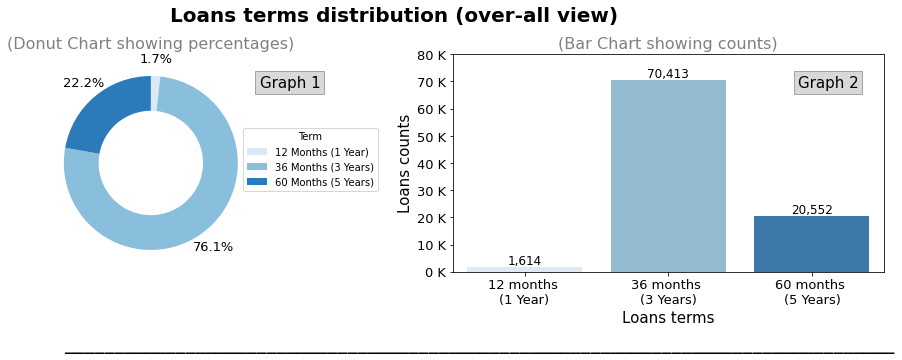

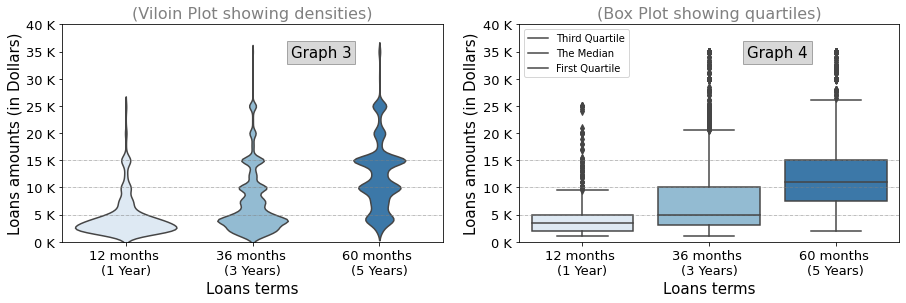

```python
plt.figure(figsize=(17,4))
plt.suptitle('Loans terms distribution (over-all view)', size=20, va='bottom', fontweight='bold')

plt.subplot(1, 2, 1) # using donut chart
plt.title('(Donut Chart showing percentages)', size=16, color='grey')
plt.pie(df.term.value_counts().sort_index(),colors = [sb.color_palette('Blues')[x] for x in [0,2,4]], startangle= 90,
        counterclock=False, autopct='%0.1f%%', textprops={'fontsize': 13}, wedgeprops = {'width' : 0.4}, pctdistance=1.2)
plt.legend(labels= ['12 Months (1 Year)', '36 Months (3 Years)', '60 Months (5 Years)'], title='Term', loc=3,bbox_to_anchor=(0.9,0.35))
plt.text(1,0.85, 'Graph 1', transform= plt.gca().transAxes, color='black', fontsize=15, bbox= {'facecolor': 'grey','alpha': 0.3})

plt.subplot(1, 2, 2) # using bar chart
plt.title('(Bar Chart showing counts)', size=16, color='grey')
sb.countplot(data=df, x='term', order= df.term.value_counts(sort=False).index
    , palette = [sb.color_palette('Blues')[x] for x in [0,2,4]])
plt.draw()
locs, labels = plt.yticks()
labels = [str(round(float(x.get_text())/1000))+ ' K' for x in labels]
plt.yticks(locs, labels, fontsize=13)
locs, labels = plt.xticks()
for loc, label in zip(locs, labels):
    count = df.term.value_counts()[float(label.get_text())]
    text = f'{count:,}'
    plt.text(loc, count+1000, text, ha = 'center', color = 'black',size=12)
plt.xticks([0,1,2],['12 months \n(1 Year)', '36 months \n(3 Years)', '60 months \n(5 Years)'], fontsize=13)
plt.xlabel('Loans terms', fontsize=15)
plt.ylabel('Loans counts', fontsize=15)
plt.text(0.8,0.85, 'Graph 2', transform= plt.gca().transAxes, color='black', fontsize=15, bbox= {'facecolor': 'grey','alpha': 0.3})
plt.text(-0.9,-0.35, '_'*82, transform= plt.gca().transAxes, color='black', fontsize=20)
plt.show()

plt.figure(figsize=(15,4))
plt.subplot(1,2,1)
plt.title('(Viloin Plot showing densities)', size=16, color='grey')
sb.violinplot(data= df, x='term', y='amount', inner=None,palette = [sb.color_palette('Blues')[x] for x in [0,2,4]])
plt.axhline(5000,color='grey', ls='-.', linewidth=0.5)
plt.axhline(10000,color='grey', ls='-.', linewidth=0.5)
plt.axhline(15000,color='grey', ls='-.', linewidth=0.5)
plt.ylim(0,40000)
plt.draw()
locs, labels = plt.yticks()
labels= [str(round(float(x.get_text())/1000))+' K' for x in labels]
plt.yticks(locs, labels, fontsize=13)
plt.xticks([0,1,2],['12 months \n(1 Year)', '36 months \n(3 Years)', '60 months \n(5 Years)'], fontsize=13)
plt.xlabel('Loans terms', fontsize=15)
plt.ylabel('Loans amounts (in Dollars)', fontsize=15)
plt.text(0.6,0.85, 'Graph 3', transform= plt.gca().transAxes, color='black', fontsize=15, bbox= {'facecolor': 'grey','alpha': 0.3})

plt.subplot(1,2,2)
plt.title('(Box Plot showing quartiles)', size=16, color='grey')
sb.boxplot(data= df, x='term', y='amount',palette = [sb.color_palette('Blues')[x] for x in [0,2,4]])
plt.legend(['Third Quartile', 'The Median', 'First Quartile'])
plt.axhline(5000,color='grey', ls='-.', linewidth=0.5)
plt.axhline(10000,color='grey', ls='-.', linewidth=0.5)
plt.axhline(15000,color='grey', ls='-.', linewidth=0.5)
plt.ylim(0,40000)
plt.draw()
locs, labels = plt.yticks()
labels= [str(round(float(x.get_text())/1000))+' K' for x in labels]
plt.yticks(locs, labels, fontsize=13)
plt.xticks([0,1,2],['12 months \n(1 Year)', '36 months \n(3 Years)', '60 months \n(5 Years)'], fontsize=13)
plt.xlabel('Loans terms', fontsize=15)
plt.ylabel('Loans amounts (in Dollars)', fontsize=15)
plt.text(0.6,0.85, 'Graph 4', transform= plt.gca().transAxes, color='black', fontsize=15, bbox= {'facecolor': 'grey','alpha': 0.3})
plt.show()
```

# Observations :

> Graph 1&2 show that borrowers prefer the intermediate period of 36-months (3 Years) with 76.1%, while terms of 12-months (1 Year) are the least wanted among borrowers with 1.7%.

> Graph 3&4 show that borrowers take loans on higher terms when applying for higher loan amounts which is logical. in the box plot graph we see that the median value of the 1-year loan is 4k, for the 3-years loan is 5k, for the 5-years loan is 11k.

## Visualization 14:

## Loans terms distribution (over the years)

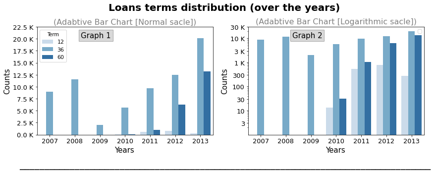

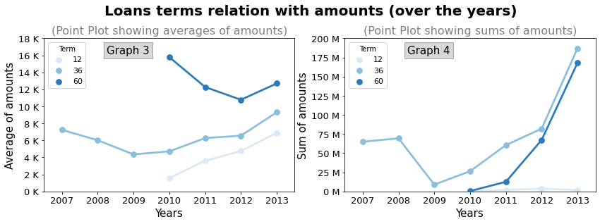

```python
plt.figure(figsize = [14, 4])

plt.suptitle('Loans terms distribution (over the years)', size=20, fontweight='bold', va='bottom')
plt.subplot(1, 2, 1)
sb.countplot(data = df, x = 'year', hue = 'term', palette = 'Blues')
plt.legend(title='Term', loc=2,prop={'size':11})
plt.draw()
locs, labels= plt.yticks()
labels= [str(float(x.get_text())/1000)+ ' K' for x in labels]
plt.yticks(locs, labels, fontsize=13)
plt.xticks(fontsize=13)
plt.title('(Adabtive Bar Chart [Normal sacle])', size=16, color='grey')
plt.xlabel('Years', fontsize=15)
plt.ylabel('Counts', fontsize=15)
plt.text(0.25,0.9, 'Graph 1', transform= plt.gca().transAxes, color='black', fontsize=15, bbox= {'facecolor': 'grey','alpha': 0.3})

plt.subplot(1, 2, 2)
sb.countplot(data = df, x = 'year', hue = 'term', palette = 'Blues')
plt.yscale('log')
ticks = [1,3,10,30,100,300,1000,3000,10000,20000]
plt.yticks(ticks,ticks)
plt.legend([])
ticks = [3,10,30,100,300,1000,3000,10000,30000]
tick_names = ['3','10','30','100','300','1 K','3 K','10 K','30 K']
plt.yticks(ticks, tick_names, fontsize=13)
plt.xticks(fontsize=13)
plt.title('(Adabtive Bar Chart [Logarithmic sacle])', size=16, color='grey')
plt.xlabel('Years', fontsize=15)
plt.ylabel('Counts', fontsize=15)
plt.text(0.25,0.9, 'Graph 2', transform= plt.gca().transAxes, color='black', fontsize=15, bbox= {'facecolor': 'grey','alpha': 0.3})
plt.text(-1.3,-0.3, '_'*82, transform= plt.gca().transAxes, color='black', fontsize=20)
plt.show()

plt.figure(figsize=(14,4))
plt.suptitle('Loans terms relation with amounts (over the years)', size=20, fontweight='bold', va='bottom')
plt.subplot(1,2,1)
plt.title('(Point Plot showing averages of amounts)', color='grey', fontsize=16)
sb.pointplot(data=df, x='year', y='amount', hue='term', markers='o', ci=None,
             palette = [sb.color_palette('Blues')[x] for x in [0,2,4]])
plt.legend(title='Term', loc=2,prop={'size':11})
plt.draw()
locs, labels= plt.yticks()
labels= [str(round(float(x.get_text())/1000))+ ' K' for x in labels]
plt.yticks(locs, labels, fontsize=13)
plt.xticks(fontsize=13)
plt.xlabel('Years', fontsize=15)
plt.ylabel('Average of amounts', fontsize=15)
plt.text(0.25,0.9, 'Graph 3', transform= plt.gca().transAxes, color='black', fontsize=15, bbox= {'facecolor': 'grey','alpha': 0.3})

plt.subplot(1,2,2)
plt.title('(Point Plot showing sums of amounts)', color='grey', fontsize=16)
sb.pointplot(data=df, x='year', y='amount', hue='term', markers='o', ci=None, estimator=sum,
             palette = [sb.color_palette('Blues')[x] for x in [0,2,4]])
plt.legend(title='Term', loc=2,prop={'size':11})
plt.ylim(0,2e8)
plt.draw()
locs, labels= plt.yticks()
labels= [str(round(float(x.get_text())*100))+ ' M' for x in labels]
plt.yticks(locs, labels, fontsize=13)
plt.xticks(fontsize=13)
plt.xlabel('Years', fontsize=15)
plt.ylabel('Sum of amounts', fontsize=15)
plt.text(0.25,0.9, 'Graph 4', transform= plt.gca().transAxes, color='black', fontsize=15, bbox= {'facecolor': 'grey','alpha': 0.3})
plt.show();
```

# Observations :

> Graph 3 shows that borrowers who apply for higher loan amounts tend to choose longer payment durations.also, we observe an increasing tendency for borrowers who choose loans on (1-year) period to apply for more loan values through the years and that might indicate a gereral increase in clients salary.

> Graph 4 shows that although 3-years loans are more than trible the numbers of 5-year loans (as seen in previous vis.) their loans sum values are very close, 14 Millions (17.6%) difference in 2012, and 18.7 Millions (10%) in 2013. so promotional investements concerning both 5-year term loans will greatly impact the total loans value.

## Visualization 15:

## Borrowers monthly incomes distribution

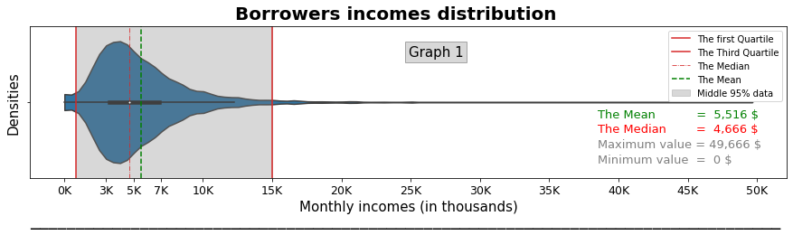

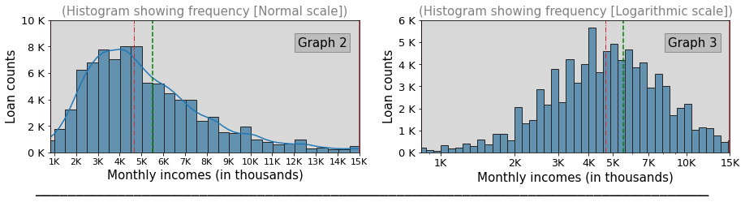

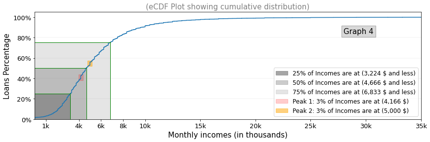

```python
plt.figure(figsize=(15,3.1))
plt.suptitle('Borrowers incomes distribution', size=20, fontweight='bold')
sb.violinplot(x=df.income, cut=0, alpha=0.8)
plt.axvspan(inaq, inbq, color='grey', alpha=0.3,label='Middle 95% data')
plt.axvline(inaq, color= alt_color, label='The first Quartile')
plt.axvline(inbq, color= alt_color, label='The Third Quartile')
plt.axvline(sq, color= alt_color, ls=('-.'), label='The Median', lw=0.8)
plt.axvline(income_mean, color= 'green', ls='--', label='The Mean')
plt.text(0.75, 0.2, 'Maximum value = '+str(f'{df.income.max():,}')+ ' $', transform= plt.gca().transAxes, color='grey', fontsize=13)
plt.text(0.75, 0.1, 'Minimum value  =  '+str(f'{df.income.min():,}')+ ' $', transform= plt.gca().transAxes, color='grey', fontsize=13)
plt.text(0.75, 0.4, 'The Mean           =  '+str(f'{round(income_mean):,}')+ ' $', transform= plt.gca().transAxes, color='green', fontsize=13)
plt.text(0.75, 0.3, 'The Median        =  '+str(f'{round(income_median):,}')+ ' $', transform= plt.gca().transAxes, color='r', fontsize=13)
plt.xlabel('Monthly incomes (in thousands)', fontsize=15)
ticks = [0,3000,5000,7000,10000,15000,20000,25000,30000,35000,40000,45000,50000]
tick_names = [str(round(float(x/1000))) + 'K' for x in ticks]
plt.xticks(ticks, tick_names, fontsize=12.5)
plt.ylabel('Densities', fontsize=15)
plt.legend(prop={'size':10}, frameon=True)
plt.text(0,-0.3, '_'*82, transform= plt.gca().transAxes, color='black', fontsize=20)
plt.text(0.5,0.8, 'Graph 1', transform= plt.gca().transAxes, color='black', fontsize=15, bbox= {'facecolor': 'grey','alpha': 0.3})
plt.show()

plt.figure(figsize=(15,3))
plt.subplot(1, 2, 1) # using normal scale
sb.histplot(df.income, color=color ,kde=True, bins=99, fill=True,edgecolor="k", linewidth=1, alpha=0.75)
ticks= np.arange(0,15001,1000)
tick_names = [str(round(x/1000))+'K' for x in ticks]
plt.xticks(ticks, tick_names, fontsize=11)
plt.xlabel('Monthly incomes (in thousands)', fontsize=15)
plt.ylabel('Loan counts', fontsize=15)
plt.axvline(sq, color= alt_color, ls=('-.'), label='The Median', lw=1)
plt.xlim(inaq,inbq)
plt.draw()
locs, labels =plt.yticks()
labels = [str(round(float(x.get_text())/1000))+ ' K' for x in labels]
plt.yticks(locs, labels, fontsize=13)
plt.axvspan(inaq, inbq, color='grey', alpha=0.3,label='Middle 50% data')
plt.axvline(inaq, color= alt_color, label='The first Quartile')
plt.axvline(inbq, color= alt_color, label='The Third Quartile')
plt.axvline(income_mean, color= 'green', ls='--', label='The Mean')
plt.text(0.8,0.8, 'Graph 2', transform= plt.gca().transAxes, color='black', fontsize=15, bbox= {'facecolor': 'grey','alpha': 0.3})
plt.title('(Histogram showing frequency [Normal scale])', fontsize=15, color='grey')

plt.subplot(1, 2, 2) # using logarithmic scale
bins = 10 ** np.arange(0, np.log10(df.income.max())+0.02, 0.03)
sb.histplot(df.income, bins=bins, fill=True, color=color, edgecolor="k", linewidth=1)
plt.xscale('log')
ticks = [1, 1000, 2000, 3000, 4000, 5000, 7000,10000, 15000]
tick_names = [str(round(x/1000))+'K' for x in ticks]
plt.xticks(ticks, tick_names, fontsize=12.5)
plt.xlabel('Monthly incomes (in thousands)', fontsize=15)
plt.ylabel('Loan counts', fontsize=15)
plt.axvline(income_median, color= alt_color, ls=('-.'), label='The Median', lw=1)
plt.draw()
locs, labels =plt.yticks()
labels = [str(round(float(x.get_text())/1000))+ ' K' for x in labels]
plt.yticks(locs, labels, fontsize=13)
plt.xlim(inaq,inbq)
plt.axvspan(inaq, inbq, color='grey', alpha=0.3,label='Middle 50% data')
plt.axvline(inaq, color= alt_color, label='The first Quartile')
plt.axvline(inbq, color= alt_color, label='The Third Quartile')
plt.axvline(income_mean, color= 'green', ls='--', label='The Mean')
plt.title('(Histogram showing frequency [Logarithmic scale])', fontsize=15, color='grey')
plt.text(-1.25,-0.3, '_'*82, transform= plt.gca().transAxes, color='black', fontsize=20)
plt.text(0.8,0.8, 'Graph 3', transform= plt.gca().transAxes, color='black', fontsize=15, bbox= {'facecolor': 'grey','alpha': 0.3})
plt.show()

plt.figure(figsize=(14,4))
plt.title('(eCDF Plot showing cumulative distribution)', fontsize=15, color='grey')
sb.ecdfplot(data=df, x='income')
plt.axvline(3220, ls='-', lw=1, color='g', ymax=0.23)
plt.axvline(4670, ls='-', lw=1, color='g', ymax=0.48)
plt.axvline(6830, ls='-', lw=1, color='g', ymax=0.72)
plt.axhline(0.2, ls='-', lw=0.1, color='grey')
plt.axhline(0.4, ls='-', lw=0.1, color='grey')
plt.axhline(0.6, ls='-', lw=0.1, color='grey')
plt.axhline(0.8, ls='-', lw=0.1, color='grey')
plt.axhline(0.25, ls='-', lw=1, color='g', xmax=0.093)
plt.axhline(0.5, ls='-', lw=1, color='g', xmax=0.132)
plt.axhline(0.75, ls='-', lw=1, color='g', xmax=0.195)
plt.xlim(0,30001)
plt.axvspan(0,3220,color='grey', alpha=0.7, ymax=0.24, label='25% of Incomes are at ('+f'{round(np.quantile(df.income, .25)):,}'+ ' $ and less)')
plt.axvspan(0,4670,color='grey', alpha=0.4, ymax=0.478, label='50% of Incomes are at ('+f'{round(np.quantile(df.income, .5)):,}'+ ' $ and less)')
plt.axvspan(0,6830,color='grey', alpha=0.2, ymax=0.718, label='75% of Incomes are at ('+f'{round(np.quantile(df.income, .75)):,}'+ ' $ and less)')
plt.legend(loc=4)
plt.draw()
locs, labels = plt.yticks()
labels= [str(round(float(x.get_text())*100))+'%' for x in labels]
plt.yticks(locs, labels, fontsize=13)
ticks=[1000,4000,6000,8000,10000,15000,20000,25000,30000,35000]
labels=[str(round(x/1000)) +'k' for x in ticks]
plt.xticks(ticks, labels, fontsize=13)
plt.ylim(0,1.05)
plt.ylabel('Loans Percentage', fontsize=15)
plt.xlabel('Monthly incomes (in thousands)', fontsize=15)
plt.text(0.8,0.8, 'Graph 4', transform= plt.gca().transAxes, color='black', fontsize=15, bbox= {'facecolor': 'grey','alpha': 0.3})
rect1 = Rectangle((3960,0.38), 400, 0.06,alpha=0.2, fill=True, color='r', label='Peak 1: 3% of Incomes are at (4,166 $)')
rect2= Rectangle((4800,0.52), 400, 0.055,alpha=0.5, fill=True, color='orange', label='Peak 2: 3% of Incomes are at (5,000 $)')
rect = [rect1, rect2]
for i in rect:
    plt.gca().add_patch(i)
plt.legend(prop={'size':12}, loc=4)
plt.show()
```

# Note :

> The income statistics shows lots of outlayers (ex:one value is 1.75 Millions/Month), so data-cleaning was perofrmed to ensure data integrity by removing incomes outlayers that exceeds (50 Thousands/Month). Graph 2 bins are of 500 Dollars intervals.

# Observations :

> Graph 1 shows that incomes mean is around 5.5k, half incomes are below 4.6k . 95% of incomes are between 830 and 15k Dollars. interestingly we find that some loaners are with no income and they represent (1.6%) of all loans.

> Graph 2&3 show a typical right-skewed pattern in normal-scale graph versus typical normal distribution pattern in the logarithmic-scale graph. the peak of incomes are between 4k-5k.

> Graph 4 shows 2 peaks (4.1k,5k) 3% each of total incomes.also, 50% of incomes are of values 4.6K and less, while 75% of incomes are of values 6.8k and less.

## Visualization 16:

## Borrowers monthly payments distribution

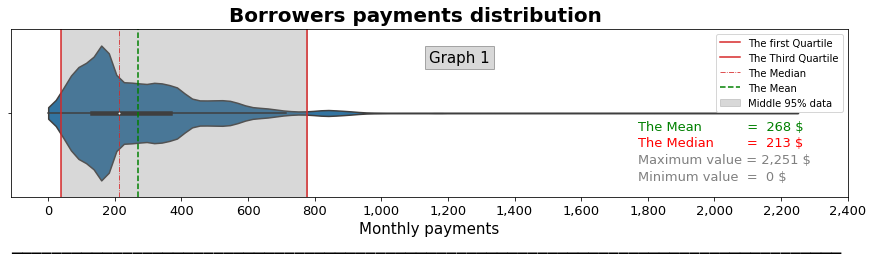

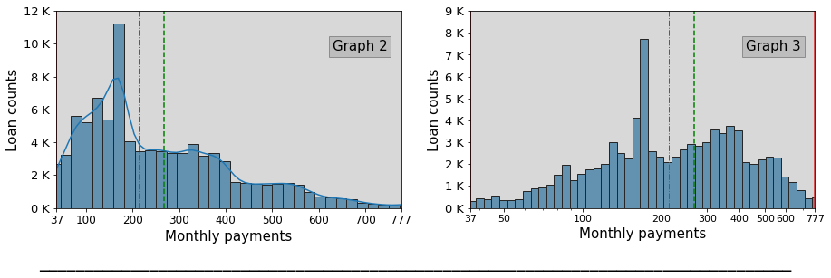

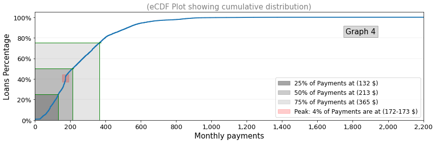

```python
plt.figure(figsize=(15,3.1))
plt.suptitle('Borrowers payments distribution', size=20, fontweight='bold')
sb.violinplot(x=df.payment, cut=0, alpha=0.8)
plt.axvspan(pyaq, pybq, color='grey', alpha=0.3,label='Middle 95% data')
plt.axvline(pyaq, color= alt_color, label='The first Quartile')
plt.axvline(pybq, color= alt_color, label='The Third Quartile')
plt.axvline(payment_median, color= alt_color, ls=('-.'), label='The Median', lw=0.8)
plt.axvline(payment_mean, color= 'green', ls='--', label='The Mean')
plt.text(0.75, 0.2, 'Maximum value = '+str(f'{df.payment.max():,}')+ ' $', transform= plt.gca().transAxes, color='grey', fontsize=13)
plt.text(0.75, 0.1, 'Minimum value  =  '+str(f'{df.payment.min():,}')+ ' $', transform= plt.gca().transAxes, color='grey', fontsize=13)
plt.text(0.75, 0.4, 'The Mean           =  '+str(f'{round(payment_mean):,}')+ ' $', transform= plt.gca().transAxes, color='green', fontsize=13)
plt.text(0.75, 0.3, 'The Median        =  '+str(f'{round(payment_median):,}')+ ' $', transform= plt.gca().transAxes, color='r', fontsize=13)
plt.xlabel('Monthly payments', fontsize=15)
ticks=np.arange(0,2401,200)
labels=[f'{x:,}' for x in ticks]
plt.xticks(ticks, labels, fontsize=13)
plt.text(0.5,0.8, 'Graph 1', transform= plt.gca().transAxes, color='black', fontsize=15, bbox= {'facecolor': 'grey','alpha': 0.3})
plt.text(0,-0.3, '_'*82, transform= plt.gca().transAxes, color='black', fontsize=20)
plt.legend(prop={'size':10}, frameon=True)
plt.show()

plt.figure(figsize=(15,4))
plt.subplot(1, 2, 1) # using normal scale
sb.histplot(df.payment, color=color ,kde=True, bins=99, fill=True,edgecolor="k", linewidth=1, alpha=0.75)
ticks = [1, 100,200,300,400,500,600,700,pyaq, pybq]
tick_names = [str(round(x)) for x in ticks]
plt.xticks(ticks, tick_names, fontsize=12)
plt.xlabel('Monthly payments', fontsize=15)
plt.ylabel('Loan counts', fontsize=15)
plt.axvline(payment_median, color= alt_color, ls=('-.'), label='The Median', lw=1)
plt.xlim(pyaq,pybq)
plt.draw()
locs, labels =plt.yticks()
labels = [str(round(float(x.get_text())/1000))+ ' K' for x in labels]
plt.yticks(locs, labels, fontsize=13)
plt.axvspan(pyaq, pybq, color='grey', alpha=0.3)
plt.axvline(pyaq, color= alt_color, label='The first Quartile')
plt.axvline(pybq, color= alt_color, label='The Third Quartile')
plt.axvline(payment_mean, color= 'green', ls='--', label='The Mean')
plt.text(0.8,0.8, 'Graph 2', transform= plt.gca().transAxes, color='black', fontsize=15, bbox= {'facecolor': 'grey','alpha': 0.3})

plt.subplot(1, 2, 2) # using logarithmic scale
bins = 10 ** np.arange(0, np.log10(df.income.max())+0.02, 0.03)
sb.histplot(df.payment, bins=bins, fill=True, color=color, edgecolor="k", linewidth=1)
plt.xscale('log')
ticks = [1, 30,50,100,200,300,400,500,600,pyaq, pybq]
tick_names = [str(round(x)) for x in ticks]
plt.xticks(ticks, tick_names, fontsize=11)
plt.xlabel('Monthly payments', fontsize=15)
plt.ylabel('Loan counts', fontsize=15)
plt.axvline(payment_median, color= alt_color, ls=('-.'), label='The Median', lw=1)
plt.draw()
locs, labels =plt.yticks()
labels = [str(round(float(x.get_text())/1000))+ ' K' for x in labels]
plt.yticks(locs, labels, fontsize=13)
plt.xlim(pyaq,pybq)
plt.axvspan(pyaq, pybq, color='grey', alpha=0.3)
plt.axvline(pyaq, color= alt_color, label='The first Quartile')
plt.axvline(pybq, color= alt_color, label='The Third Quartile')
plt.axvline(payment_mean, color= 'green', ls='--', label='The Mean')
plt.text(0.8,0.8, 'Graph 3', transform= plt.gca().transAxes, color='black', fontsize=15, bbox= {'facecolor': 'grey','alpha': 0.3})
plt.text(-1.25,-0.3, '_'*82, transform= plt.gca().transAxes, color='black', fontsize=20)
plt.show()

plt.figure(figsize=(14,4))
plt.title('(eCDF Plot showing cumulative distribution)', fontsize=15, color='grey')
sb.ecdfplot(data=df, x='payment', lw=2)
plt.axvline(132, ls='-', lw=1, color='g', ymax=0.23)
plt.axvline(213, ls='-', lw=1, color='g', ymax=0.48)
plt.axvline(365, ls='-', lw=1, color='g', ymax=0.72)
plt.axhline(0.2, ls='-', lw=0.1, color='grey')
plt.axhline(0.4, ls='-', lw=0.1, color='grey')
plt.axhline(0.6, ls='-', lw=0.1, color='grey')
plt.axhline(0.8, ls='-', lw=0.1, color='grey')
plt.axhline(0.25, ls='-', lw=1, color='g', xmax=0.06)
plt.axhline(0.5, ls='-', lw=1, color='g', xmax=0.1)
plt.axhline(0.75, ls='-', lw=1, color='g', xmax=0.17)
plt.xlim(0,2100)
plt.axvspan(0,132,color='grey', alpha=0.7, ymax=0.24, label='25% of Payments at ('+f'{round(np.quantile(df.payment, .25)):,}'+ ' $)')
plt.axvspan(0,213,color='grey', alpha=0.4, ymax=0.478, label='50% of Payments at ('+f'{round(np.quantile(df.payment, .5)):,}'+ ' $)')
plt.axvspan(0,365,color='grey', alpha=0.2, ymax=0.718, label='75% of Payments at ('+f'{round(np.quantile(df.payment, .75)):,}'+ ' $)')
plt.legend(loc=4)
plt.draw()
locs, labels = plt.yticks()
labels= [str(round(float(x.get_text())*100))+'%' for x in labels]
plt.yticks(locs, labels, fontsize=13)
ticks=np.arange(0,2300,200)
labels=[f'{x:,}' for x in ticks]
plt.xticks(ticks, labels, fontsize=13)
plt.ylim(0,1.05)
plt.ylabel('Loans Percentage', fontsize=15)
plt.xlabel('Monthly payments', fontsize=15)
plt.text(0.8,0.8, 'Graph 4', transform= plt.gca().transAxes, color='black', fontsize=15, bbox= {'facecolor': 'grey','alpha': 0.3})
rect = Rectangle((155,0.37), 35, 0.075,alpha=0.2, fill=True, color='r', label='Peak: 4% of Payments are at (172-173 $)')
plt.gca().add_patch(rect)
plt.legend(prop={'size':12}, loc=4)
plt.show()
```